# CNN-Project

```
We use the diferent weights to initialize, Conv2D:zerosDenses: zeros
Train on 60000 samples, validate on 10000 samples
```

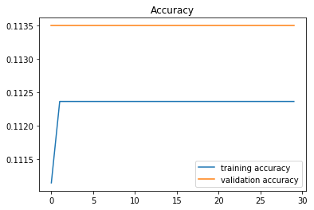

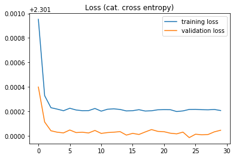

[output not shown]

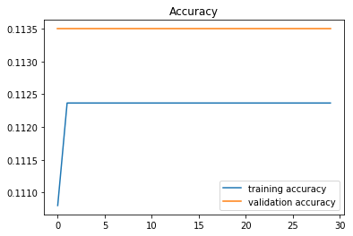

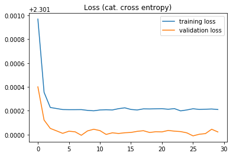

```
Baseline Error: 0.80%

 The best parameters are:
 Accuracy = 0.11350000001192093
 Loss = 2.3012236181894936
We use the diferent weights to initialize, Conv2D:zerosDenses: random
Train on 60000 samples, validate on 10000 samples
```

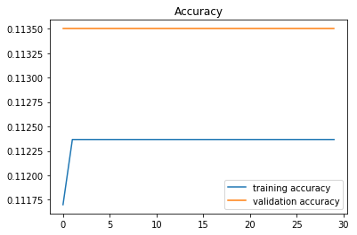

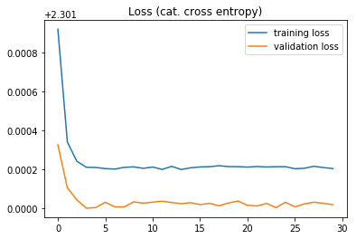

```
Baseline Error: 0.80%

 The best parameters are:
 Accuracy = 0.11350000001192093
 Loss = 2.3012236181894936
We use the diferent weights to initialize, Conv2D:zerosDenses: he_normal
Train on 60000 samples, validate on 10000 samples
```

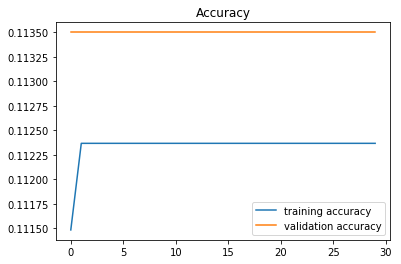

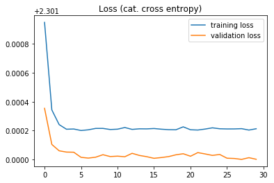

```
Baseline Error: 0.80%

 The best parameters are:
 Accuracy = 0.11350000001192093
 Loss = 2.3012236181894936
We use the diferent weights to initialize, Conv2D:xavierDenses: zeros
Train on 60000 samples, validate on 10000 samples
```

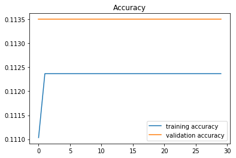

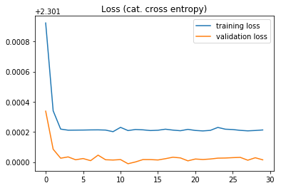

```
Baseline Error: 0.80%

 The best parameters are:
 Accuracy = 0.11350000001192093
 Loss = 2.3012236181894936
We use the diferent weights to initialize, Conv2D:xavierDenses: xavier
Train on 60000 samples, validate on 10000 samples
```

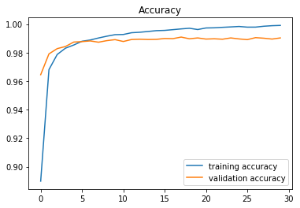

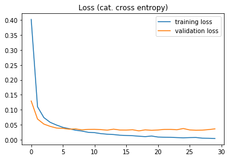

```
Baseline Error: 0.80%
Conv2D: xavierDenses: xavier

 The best parameters are:
 Accuracy = 0.9890999996185302
 Loss = 0.024345019531746705
We use the diferent weights to initialize, Conv2D:xavierDenses: random
Train on 60000 samples, validate on 10000 samples
```

[20 more figures not shown]

```
Baseline Error: 0.80%

 The best parameters are:
 Accuracy = 0.9889999996185302
 Loss = 0.01783749522368113
```

```python
weightsInit = {
    'Conv2D': ['zeros','xavier', 'random', 'he_normal'],
    'Dense': ['zeros','xavier', 'random', 'he_normal']
}
WInits = list(ParameterSampler(weightsInit, n_iter = 16 ))
for initType in WInits:
    print ("We use the diferent weights to initialize, Conv2D:" + initType['Conv2D'] + "Denses: " + initType['Dense'])
    history = train_model_weights(initType)
    plot_accuracy(history)
    plot_loss(history)
    scores = model.evaluate(X_test, y_test, verbose=0)
    print("Baseline Error: %.2f%%" % (100-scores[1]*100))
```

We select the better batch size to try the different weights initializations. To this initializations we try several functions to initializaize the weights: Xavier, Zeros, Random and He. We use all the combinations with these initializations for conv and dense layers. We used 30 epochs because we see that with 10 the accuracy didn't take the maximum value and still increasing. We obtain diferents initializations as better, in train the better weight initialization was Xavier for the Conv and Denses layers, with an accuracy of 0.9991. But the better weight initialization in validation was Random for both type of layers with an accuracy of 0.9905. We can see also that all the initializations give us a good results except when some of the layers is initialized with Zeros that give us accuracy values of arround 0.113.